# Course WriteUp

For the project, my final model was a gaussian kernel SVM with hyperparameters `C = 10000` and `sigma = 0.0169`. Necessary libraries are `caret`,`kernlab`, and `e1071`.

## 1) Removing bad features

Before any partitioning of the data, I first inspected the data for bad features in the following code. Any features containing NANs selected for removal (`nainds`). To remove low variance predictors, `nearZeroVar` with default parameters was used (`smallvarinds`). The first 7 features were also removed because they contained irrelevant metadata that would cause overfitting (`userselectedinds`).

```r
data.raw <- read.csv(file="pml-training.csv", header=TRUE, sep=",")

smallvarinds = nearZeroVar(data.raw)
nainds = which(vapply(data.raw, function(x){sum(is.na(x))>0}, TRUE))
userselectedinds = 1:7

removedindices = unique(c(nainds, smallvarinds, userselectedinds))
data.raw <- data.raw[,-removedindices]
```

52 predictors were kept.

## 2) Partitioning data

60% of the observations were used for training.

```r
inTrain <- createDataPartition(y=data.raw$classe, p=0.6,list=FALSE)
training <- data.raw[inTrain,]
testing <- data.raw[-inTrain,]
```

## 3) Training and cross validation

I experimented with three classifiers:

- Gradient Boosted Classification Trees using `gbm` within `caret`
- Gaussian Kernel SVM using `ksvm` from `kernlab`
- K-Nearest Neighbors using `knn3` within `caret`

I performed *10-fold cross validation* with no repetitions. For `gbm` and `knn3`, I used the `trControl` parameter with the following value.

```r
## train control options
fitControl <- trainControl(method = "repeatedcv",
                           number = 10,
                           repeats = 1,
                           )
```

For the SVM C hyperparameter, this was tuned with `tune.svm` from package `e1071`. Similarly the K-Nearest Neighbors k parameter was tuned using values 1,3,5,7,and 9. To save on time, the parameters of the Gradient Boosted Model were chosen by recommendations from the community.

## 4) Evaluation on test set

After training the models, they were used to predict the testing data.

```r
## predict after training
preds.gbm = predict(model.gbm,newdata=testing)
preds.svm = predict(model.svm,newdata=testing)
preds.knn = predict(model.knn, newdata=testing)
```

To compare the classifiers, a plot was generated comparing the balanced accuracies:

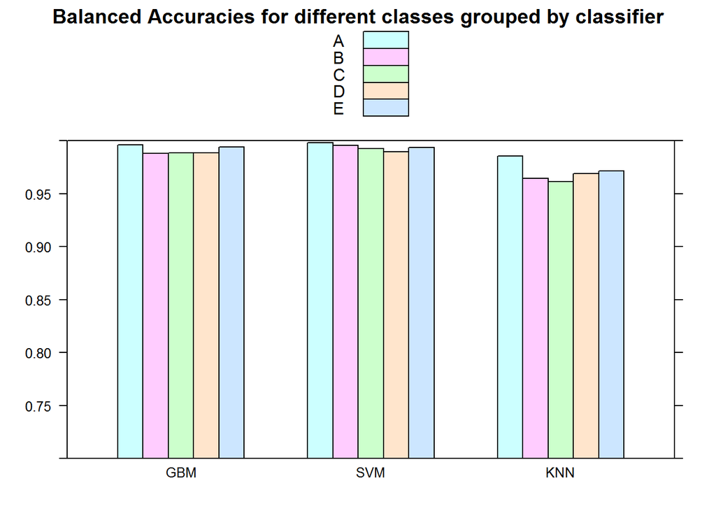

```r
actual = testing$classe

ba = data.frame()
cf.gbm = confusionMatrix(preds.gbm, actual)
ba = rbind(ba, data.frame(type = rep('GBM',5), class = c("A", "B", "C","D","E"),acc = cf.gbm$byClass[,8]))
cf.svm = confusionMatrix(preds.svm, actual)
ba = rbind(ba, data.frame(type = rep('SVM',5), class = c("A", "B", "C","D","E"),acc = cf.svm$byClass[,8]))
cf.knn = confusionMatrix(preds.knn, actual)
ba = rbind(ba, data.frame(type = rep('KNN',5), class = c("A", "B", "C","D","E"),acc = cf.knn$byClass[,8]))

library(lattice)
barchart(acc~type,data=ba,groups=class, main="Balanced Accuracies for different classes grouped by classifier", ylim=c(0.7, 1), auto.key=TRUE, ylab="")
```

SVM slightly outperformed GBM. A closer view will reveal the major differences.

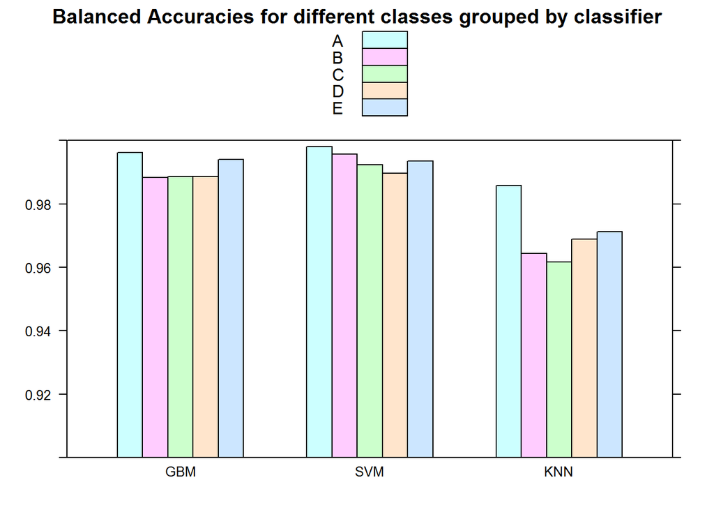

```r
library(lattice)
barchart(acc~type,data=ba,groups=class, main="Balanced Accuracies for different classes grouped by classifier", ylim=c(0.9, 1), auto.key=TRUE, ylab="")
```

GBM and SVM seem to be somewhat the same, where as KNN falls behind.

To get a better sense of how whether SVM or GBM is the more robust classifiers, I performed classification once more on the *first 5 principal components*. The idea was to see how the accuruacies dropped when a lot of information was removed. The plot from this procedure was shown below:

```r
#perform pca

end = ncol(training)
preObj <- preProcess(training[,-end],method="pca", pcaComp=5)
pcatraining <- predict(preObj, training[,-end])
pcatraining$classe <-training$classe

pca.model.svm <- ksvm(classe~.,data=pcatraining,kernel="rbfdot",C=10000, cross=10)
pca.model.gbm <- train(classe ~ .,data=pcatraining, method="gbm", tuneGrid=gbmGrid,trControl=fitControl)
pca.model.knn <- train(classe ~ ., data=pcatraining, method="knn", tuneGrid = knnGrid,trControl=fitControl)

pcatesting = predict(preObj, testing[,-end])
pca.preds.gbm = predict(pca.model.gbm, newdata=pcatesting)
pca.preds.svm = predict(pca.model.svm, newdata=pcatesting)
pca.preds.knn = predict(pca.model.knn, newdata=pcatesting)

pca.ba = data.frame()
pca.cf.gbm = confusionMatrix(pca.preds.gbm, actual)
pca.ba = rbind(pca.ba, data.frame(type = rep('GBM',5), class = c("A", "B", "C","D","E"),acc = pca.cf.gbm$byClass[,8]))
pca.cf.svm = confusionMatrix(pca.preds.svm, actual)
pca.ba = rbind(pca.ba, data.frame(type = rep('SVM',5), class = c("A", "B", "C","D","E"),acc = pca.cf.svm$byClass[,8]))
pca.cf.knn = confusionMatrix(pca.preds.knn, actual)
pca.ba = rbind(pca.ba, data.frame(type = rep('KNN',5), class = c("A", "B", "C","D","E"),acc = pca.cf.knn$byClass[,8]))
```

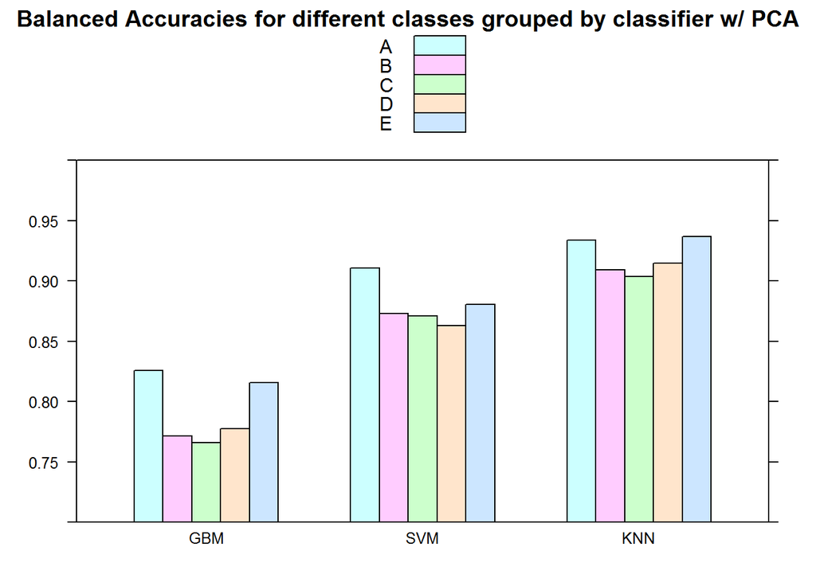

```r
library(lattice)
barchart(acc~type,data=pca.ba,groups=class, main="Balanced Accuracies for different classes grouped by classifier w/ PCA", ylim=c(0.7, 1), auto.key=TRUE, ylab="")
```

From the two plots above I decided to use SVM as the final classifier, since it had less of a drop in accuracy after dimensionality reduction.

## 5) Out of sample error estimation

Out-of-sample error estimation was based on the accuracy reported on the testing set predictions for the SVM classifier.

```r
print(cf.svm$overall)
```

```
##       Accuracy          Kappa  AccuracyLower  AccuracyUpper   AccuracyNull
##         0.9908         0.9884         0.9885         0.9928         0.2845
## AccuracyPValue  McnemarPValue
##         0.0000            NaN
```

```r
error = 1-cf.svm$overall[1]
print(error)
```

```
## Accuracy
## 0.009177
```